# ANLY506 Final Report

Tu Nguyen

4/16/2019

# Bike Vendors Project Executive Summary

The Bike Vendor dataset contains 97 observations and 35 variables. It provides 4 types of information: the bike usage, frame materials, price, and distribution of all models going by each vendor (which might represents as either the percentage of inventory held or the percentage of sales contribution). The objective of this project is to break down the data to gain insights into (1) price variation between 97 models, and (2) models distribution across 30 vendors.

The data visualization will also be integrated into the project to examine the correlativity between different parameters.

# Research Questions

1. Which models are the cheapest and most expensive?
2. What is the relationship between price and different bike types? (price versus variables category 1, category 2, and frame)
3. Which types of bikes are most popular if being grouped by category 1, category 2, and frame?
4. Which models are most popular across 30 vendors?

# Loading packages and data

```r
library(readr)
bikevendors <- read_csv("/Users/tunguyen/Downloads/bikeVendors.csv")
dim(bikevendors)
```

```
## [1] 97 35
```

The dataset contains 97 observations, 35 varibles and no missing values. Below is the sneak peek of the raw data structure.

```r
head(bikevendors)
```

```
## # A tibble: 6 x 35
##   model category1 category2 frame price `Albuquerque Cy… `Ann Arbor Spee…
##   <chr> <chr>     <chr>     <chr> <dbl>            <dbl>            <dbl>
## 1 Bad … Mountain  Trail     Alum…  3200          0.0175           0.00664
## 2 Bad … Mountain  Trail     Alum…  2660          0.00699          0.00997
## 3 Beas… Mountain  Trail     Alum…  2770          0.0105           0.0150
## 4 Beas… Mountain  Trail     Alum…  2130          0.0105           0.00997
## 5 Beas… Mountain  Trail     Alum…  1620          0.00350          0.00332
## 6 CAAD… Road      Elite Ro… Alum…  2660          0.0140           0.0266
## # … with 28 more variables: `Austin Cruisers` <dbl>, `Cincinnati
## #   Speed` <dbl>, `Columbus Race Equipment` <dbl>, `Dallas Cycles` <dbl>,
## #   `Denver Bike Shop` <dbl>, `Detroit Cycles` <dbl>, `Indianapolis
## #   Velocipedes` <dbl>, `Ithaca Mountain Climbers` <dbl>, `Kansas City
## #   29ers` <dbl>, `Las Vegas Cycles` <dbl>, `Los Angeles Cycles` <dbl>,
## #   `Louisville Race Equipment` <dbl>, `Miami Race Equipment` <dbl>,
## #   `Minneapolis Bike Shop` <dbl>, `Nashville Cruisers` <dbl>, `New
## #   Orleans Velocipedes` <dbl>, `New York Cycles` <dbl>, `Oklahoma City
## #   Race Equipment` <dbl>, `Philadelphia Bike Shop` <dbl>, `Phoenix
## #   Bi-peds` <dbl>, `Pittsburgh Mountain Machines` <dbl>, `Portland
## #   Bi-peds` <dbl>, `Providence Bi-peds` <dbl>, `San Antonio Bike
## #   Shop` <dbl>, `San Francisco Cruisers` <dbl>, `Seattle Race
## #   Equipment` <dbl>, `Tampa 29ers` <dbl>, `Wichita Speed` <dbl>
```

## List of variables

```r
colnames(bikevendors)
```

```
##  [1] "model"                        "category1"
##  [3] "category2"                    "frame"
##  [5] "price"                        "Albuquerque Cycles"
##  [7] "Ann Arbor Speed"              "Austin Cruisers"
##  [9] "Cincinnati Speed"             "Columbus Race Equipment"
## [11] "Dallas Cycles"                "Denver Bike Shop"
## [13] "Detroit Cycles"               "Indianapolis Velocipedes"
## [15] "Ithaca Mountain Climbers"     "Kansas City 29ers"
## [17] "Las Vegas Cycles"             "Los Angeles Cycles"
## [19] "Louisville Race Equipment"    "Miami Race Equipment"
## [21] "Minneapolis Bike Shop"        "Nashville Cruisers"
## [23] "New Orleans Velocipedes"      "New York Cycles"
## [25] "Oklahoma City Race Equipment" "Philadelphia Bike Shop"
## [27] "Phoenix Bi-peds"              "Pittsburgh Mountain Machines"
## [29] "Portland Bi-peds"             "Providence Bi-peds"
## [31] "San Antonio Bike Shop"        "San Francisco Cruisers"
## [33] "Seattle Race Equipment"       "Tampa 29ers"
## [35] "Wichita Speed"
```

## Answer to question 1

```r
summary(bikevendors$price)
```

```
##    Min. 1st Qu.  Median    Mean 3rd Qu.    Max.
##     415    1950    3200    3954    5330   12790
```

The cheapest bike costs $415, while the most expensive one is $12,790,

```r
df1<- select(bikevendors, model, category1, category2, frame, price)
subset(df1, price==415 |
         price==12790)
```

```
## # A tibble: 3 x 5
##   model                   category1 category2          frame    price
##   <chr>                   <chr>     <chr>              <chr>    <dbl>
## 1 Catalyst 4              Mountain  Sport              Aluminum   415
## 2 Scalpel-Si Black Inc.   Mountain  Cross Country Race Carbon   12790
## 3 Supersix Evo Black Inc. Road      Elite Road         Carbon   12790
```

It can be seen the cheapest model is Catalyst 4, whereas Scalpel-Si Black Inc. and Supersiz Evo Black Inc. are the most expensive ones.

## Answer to question 2

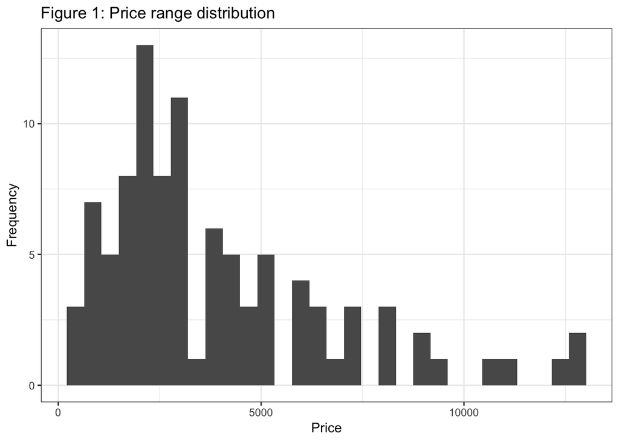

```r
g1<- ggplot(bikevendors, aes(x=price))
g1+ geom_histogram(aes(fill=price)) + ggtitle("Figure 1: Price range distribution") +
  xlab("Price") + ylab("Frequency") +
  theme_bw()
```

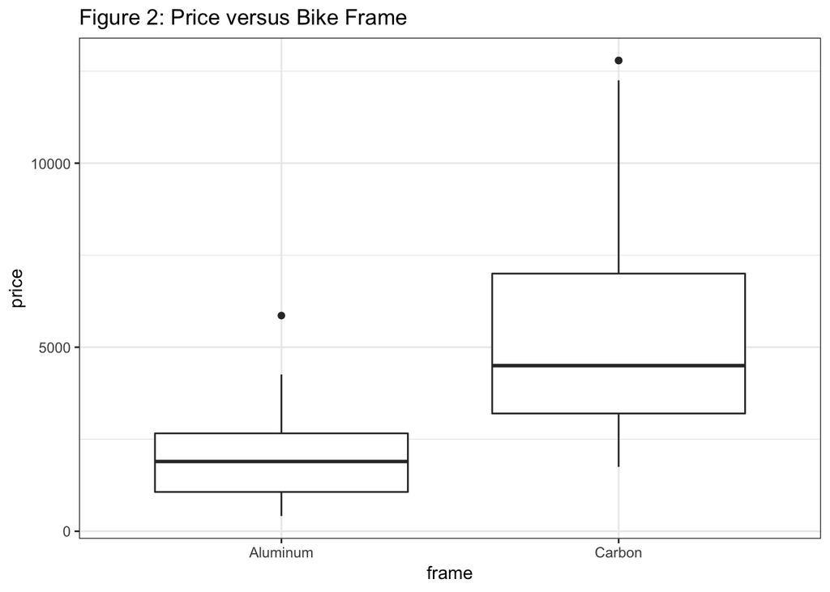

```r
g2<- ggplot(bikevendors, aes(x=frame, y= price, fill=frame))
g2 + geom_boxplot(aes(fill=price)) +
  ggtitle("Figure 2: Price versus Bike Frame")+
  theme_bw()
```

Besides that there are more models made with carbon, bikes with carbon frame are generally more expensive than aluminum ones.

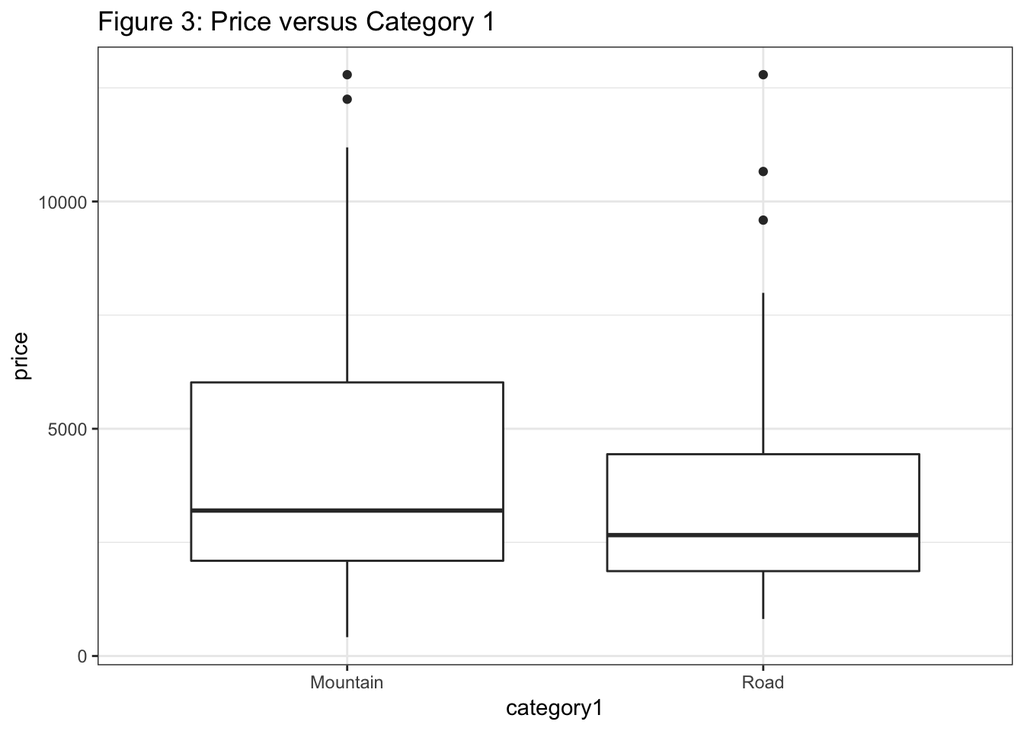

```r
g3<- ggplot(bikevendors, aes(x=category1, y= price, fill=category1))
g3 + geom_boxplot(aes(fill=price)) +
  ggtitle("Figure 3: Price versus Category 1")+
  theme_bw()
```

Figure 3 shows that despite the outliers, the average price of mountain bikes are slighly more expensive than of road bikes.

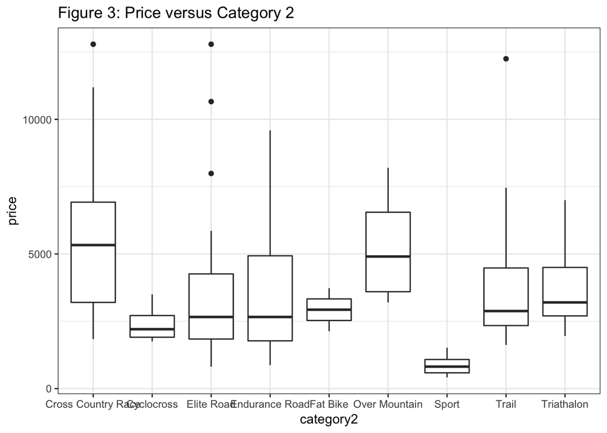

```r
g4<- ggplot(bikevendors, aes(x=category2, y= price, fill=category2))
g4 + geom_boxplot(aes(fill=price)) +
  ggtitle("Figure 3: Price versus Category 2")+
  theme_bw()
```

Among all bikes within category 2, Cross Country Road bikes have the highest average price compared to the other 8.

## Answer to question 3

```r
bike<- bikevendors %>% group_by(category1, category2) %>% summarize(count = n()) %>% arrange(count)
bike
```

```
## # A tibble: 9 x 3
## # Groups:   category1 [2]
##   category1 category2          count
##   <chr>     <chr>              <int>
## 1 Mountain  Fat Bike               2
## 2 Road      Cyclocross             4
## 3 Road      Triathalon             5
## 4 Mountain  Over Mountain          8
## 5 Mountain  Sport                  9
## 6 Mountain  Trail                 13
## 7 Road      Endurance Road        16
## 8 Mountain  Cross Country Race    19
## 9 Road      Elite Road            21
```

We learn that Elite Road is the most popular type of bike, with a total of 21 counts.

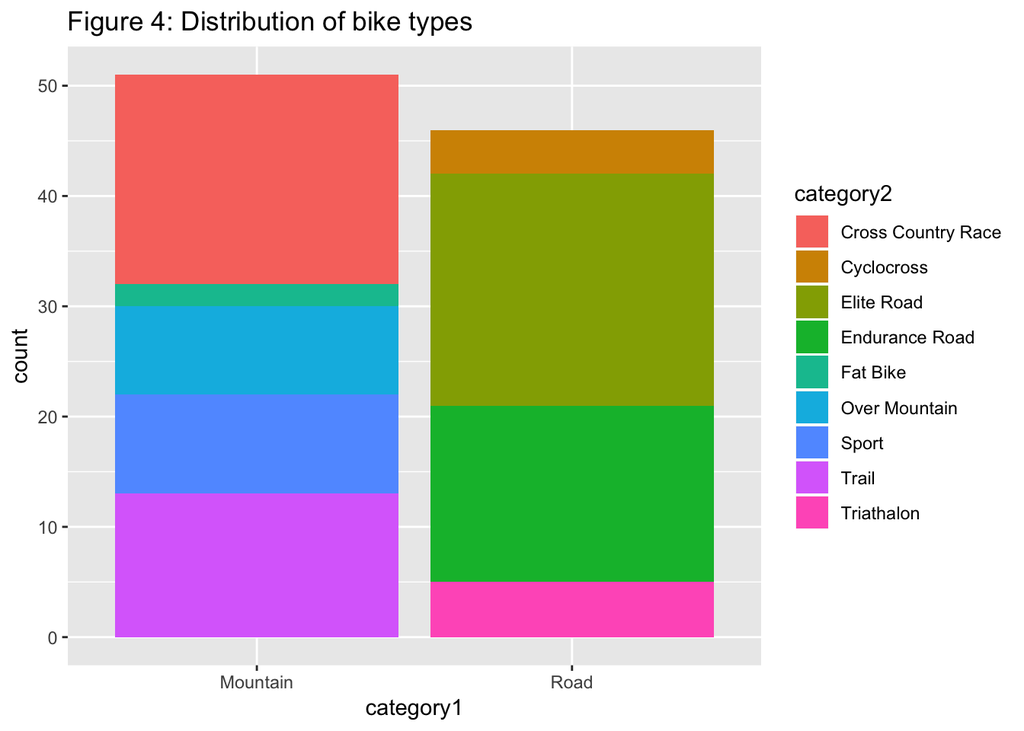

```r
g4<- ggplot(bikevendors, aes(category1, fill= category2))
g4+geom_bar(aes()) + ggtitle("Figure 4: Distribution of bike types")
```